# Titanic_prediction

Barbora Ferusová - (barbora.ferusova@gmail.com)

Last edited: 2024-03-09

# Titanic prediction: Predicting Titanic survival on Logistic Regression Models

### **Coding Skills Showcased:**

- Data cleaning and preprocessing
- Exploratory data analysis
- Logistic regression modeling
- Interpretation of model coefficients and statistical metrics
- Predicting probabilities based on a model
- Data visualization and presentation of results This project demonstrates a comprehensive skill set in data cleaning, exploratory analysis, logistic regression modeling, and statistical validation, essential for data-driven research and decision-making.

### Intro:

Over a century after the Titanic’s tragic voyage, modern data analysis allows us to unravel the factors behind its infamous passenger survival rates. This project aims to employ logistic regression to predict survival outcomes, offering insights into historical data’s impact on contemporary data-driven decision-making.

### Methods:

The dataset comprises details of 887 passengers on board the Titanic such as age, sex, and class, pivotal in understanding survival patterns. Logistic regression was chosen for its efficacy in binary outcome prediction, leveraging these variables to ascertain survival likelihood. Data preprocessing included handling missing values and creating dummy variables for categorical data, essential for a robust analysis. Assumptions of a logistic regression were tested.

### Results:

The model had the following syntax:

- **Eq 1: Survived ~ Age + Sex + Pclass**

(The Pclass variable points to the travel class of passengers: 1st, 2nd and 3rd)

### Statistical Validity:

Model validation included assessing fit through residual analysis and ensuring no multicollinearity among predictors. Metrics like accuracy, precision, and recall were calculated, demonstrating the model’s predictive strength and reliability in historical data interpretation.

In conclusion, these values of accuracy are better than what would be obtained by chance. It therefore points us to the consensus that information such as age, sex and class can be used to successfully predict the survival of a catastrophe.

### Loading and formatting data

```r
# load data, set variable types like factor or numerical
# deselect unused variables
titanic_df <- read_csv('data/titanic.csv',
                       col_types = c(Survived = "f",Pclass = "f",
                                     Name = "f",Sex = "f",Age = "n")) %>%
            select(-c("Siblings/Spouses Aboard", "Parents/Children Aboard", "Fare"))
```

# 1 Titanic Survival Analysis

```r
# create a random ID for anonimity
titanic_df$Name <- as.factor(titanic_df$Name)
titanic_df$Name <- as.numeric(titanic_df$Name)
titanic_df$Name <- as.factor(titanic_df$Name)
```

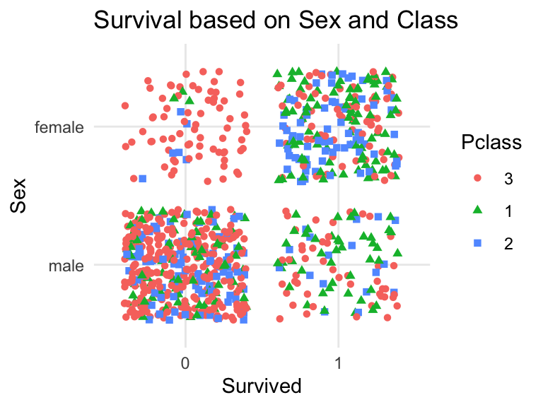

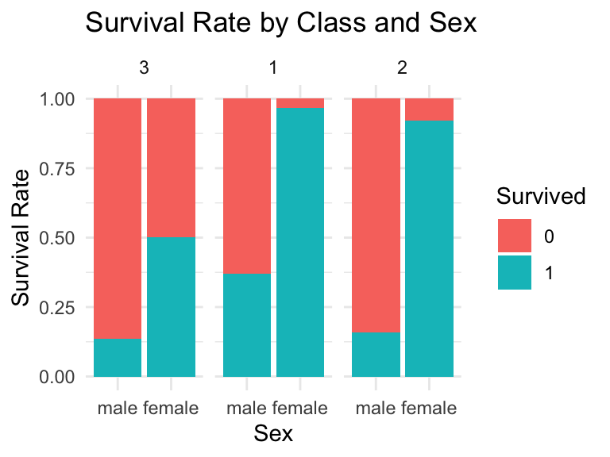

```r
# Faceted plot for Survival Rate by Class and Sex
ggplot(titanic_df, aes(x = Sex, fill = Survived)) +
  geom_bar(position = 'fill') +
  facet_grid(~ Pclass) +
  labs(y = 'Survival Rate', title = 'Survival Rate by Class and Sex') +
  theme_minimal()
```

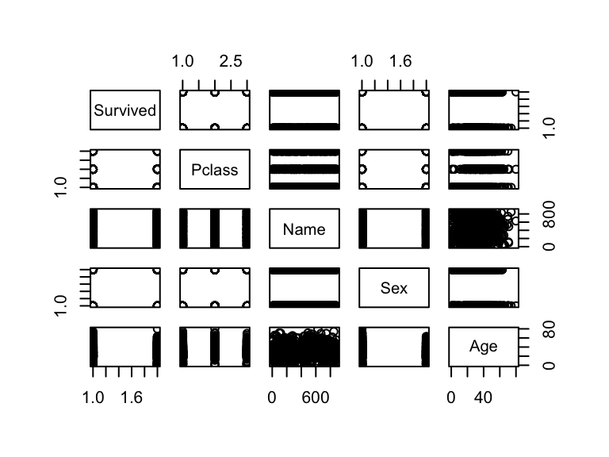

```r
plot(titanic_df)
```

```r
# Creating a binary variable to indicate if the passenger's age is the median age
titanic_df <- titanic_df %>%
              mutate(isMedianAge = as.factor(Age == median(Age)))
```

```r
# I put in my equation into a basic model using glm()
general_model <- glm(Survived ~ Sex + Age + Pclass, family = binomial(link=logit),
                                      data = titanic_df)

# play around with the equation
tit_1 <- glm(Survived ~ Sex + isMedianAge + Pclass, family = binomial(link=logit),
                                      data = titanic_df)
summary(tit_1) # summarize model
```

```
##
## Call:
## glm(formula = Survived ~ Sex + isMedianAge + Pclass, family = binomial(link = logit),
##     data = titanic_df)
##
## Coefficients:
##                 Estimate Std. Error z value Pr(>|z|)
## (Intercept)      -2.2224     0.1599 -13.900  < 2e-16 ***
## Sexfemale         2.6361     0.1843  14.301  < 2e-16 ***
## isMedianAgeTRUE  -0.4430     0.4503  -0.984    0.325
## Pclass1           1.8926     0.2146   8.820  < 2e-16 ***
## Pclass2           1.0633     0.2203   4.827 1.38e-06 ***
## ---
## Signif. codes:  0 '***' 0.001 '**' 0.01 '*' 0.05 '.' 0.1 ' ' 1
##
## (Dispersion parameter for binomial family taken to be 1)
##
##     Null deviance: 1182.77  on 886  degrees of freedom
## Residual deviance:  825.08  on 882  degrees of freedom
## AIC: 835.08
##
## Number of Fisher Scoring iterations: 4
```

```r
# create a table for the general model
knitr::kable(summary(general_model)$coefficients, caption = "Logistic regression model: Survived ~ Sex + Age + Pclass")
```

Logistic regression model: Survived ~ Sex + Age + Pclass

|  | Estimate | Std. Error | z value | Pr(>\|z\|) |
| --- | --- | --- | --- | --- |
| (Intercept) | -1.409242 | 0.2270018 | -6.208069 | 0.0e+00 |
| Sexfemale | 2.588720 | 0.1870063 | 13.842959 | 0.0e+00 |
| Age | -0.034275 | 0.0071601 | -4.786950 | 1.7e-06 |
| Pclass1 | 2.455443 | 0.2532233 | 9.696747 | 0.0e+00 |
| Pclass2 | 1.256328 | 0.2264647 | 5.547564 | 0.0e+00 |

Logistic regression is used due to its effectiveness in handling binary outcome variables, like survival in the Titanic dataset.

```r
# Set up cross-validation using 10-fold CV
set.seed(123)  # for reproducibility
train_control <- trainControl(method = "cv", number = 10)

# Fit the model with cross-validation
cv_model <- train(Survived ~ Sex + Age + Pclass,
                  data = titanic_df,
                  method = "glm",
                  family = binomial(link = "logit"),
                  trControl = train_control)

# Print the results
print(cv_model)
```

```
## Generalized Linear Model
##
## 887 samples
##   3 predictor
##   2 classes: '0', '1'
##
## No pre-processing
## Resampling: Cross-Validated (10 fold)
## Summary of sample sizes: 798, 798, 799, 799, 797, 799, ...
## Resampling results:
##
##   Accuracy   Kappa
##   0.7936108  0.5602582
```

```r
# Summarize the cross-validation results
summary(cv_model)
```

```
##
## Call:
## NULL
##
## Coefficients:
##             Estimate Std. Error z value Pr(>|z|)
## (Intercept) -1.40924    0.22700  -6.208 5.36e-10 ***
## Sexfemale    2.58872    0.18701  13.843  < 2e-16 ***
## Age         -0.03427    0.00716  -4.787 1.69e-06 ***
## Pclass1      2.45544    0.25322   9.697  < 2e-16 ***
## Pclass2      1.25633    0.22646   5.548 2.90e-08 ***
## ---
## Signif. codes:  0 '***' 0.001 '**' 0.01 '*' 0.05 '.' 0.1 ' ' 1
##
## (Dispersion parameter for binomial family taken to be 1)
##
##     Null deviance: 1182.77  on 886  degrees of freedom
## Residual deviance:  801.59  on 882  degrees of freedom
## AIC: 811.59
##
## Number of Fisher Scoring iterations: 5
```

**Cross-validation explanation:** The output presents a generalized linear model (GLM) for predicting the survival of passengers on the Titanic, using logistic regression. The model includes three predictors: Sex, Age, and Pclass (passenger class).

Accuracy: The average accuracy across the 10-fold cross-validation is approximately 79.36%. This means the model correctly predicts survival 79.36% of the time across different subsets of the data.

Kappa: The Cohen’s Kappa score is 0.5603, suggesting a moderate level of agreement between the model’s predictions and the actual outcomes, corrected for chance. This is an indication that the model is performing significantly better than random guessing.

**Coefficients:**

(Intercept): The base log-odds of survival, when all predictor variables are 0, is -1.40924. This negative value indicates a low probability of survival when all predictors are at their reference level.

**Sex (female):** With an estimate of 2.58872, being female is a strong positive predictor of survival. The positive coefficient implies that females had a much higher probability of surviving than males, holding all other variables constant.

**Age:** The coefficient of -0.03427 indicates that the probability of survival decreases with increasing age. Each additional year of age slightly reduces the log-odds of surviving.

**Pclass1 and Pclass2:** The positive coefficients for Pclass1 (2.45544) and Pclass2 (1.25633) suggest that passengers in the first and second class had higher odds of survival compared to those in the third class (the reference category).

**Statistical Significance:** All predictors have very low p-values (less than 0.05), indicating that the effects are statistically significant and unlikely to be due to random chance.

**Model Fit:** The decrease from the null deviance (1182.77) to the residual deviance (801.59) demonstrates that the model with predictors provides a significantly better fit to the data than the null model, which only includes the intercept.

**AIC (Akaike Information Criterion):** The AIC of the model is 811.59, which provides a measure of the relative quality of the model for the given set of data. Lower AIC values generally indicate a better model, but it is mostly used for comparison between different models.

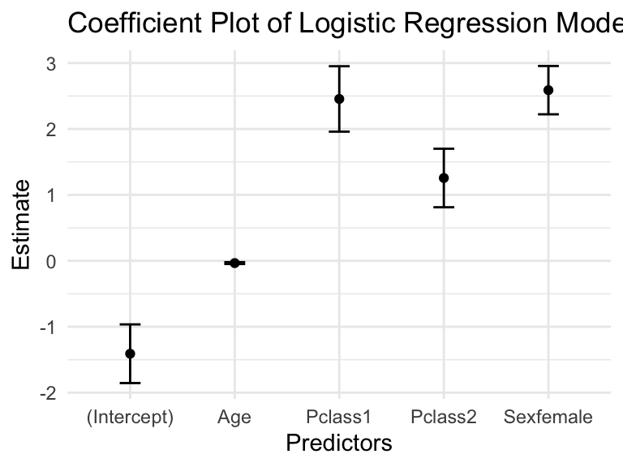

```r
# Extract model coefficients and standard errors
coef_df <- summary(general_model)$coefficients %>%
  as.data.frame() %>%
  rownames_to_column(var = "Variable")

coef_df <- coef_df %>%
  mutate(Lower = Estimate - 1.96 * `Std. Error`,
         Upper = Estimate + 1.96 * `Std. Error`)

# Create coefficient plot
ggplot(coef_df, aes(x = Variable, y = Estimate)) +
  geom_point() +
  geom_errorbar(aes(ymin = Lower, ymax = Upper), width = 0.2) +
  theme_minimal() +
  labs(title = "Coefficient Plot of Logistic Regression Model",
       x = "Predictors",
       y = "Estimate")
```

Here we can see how much each predictor influences the outcome and the standard deviation of that estimate.

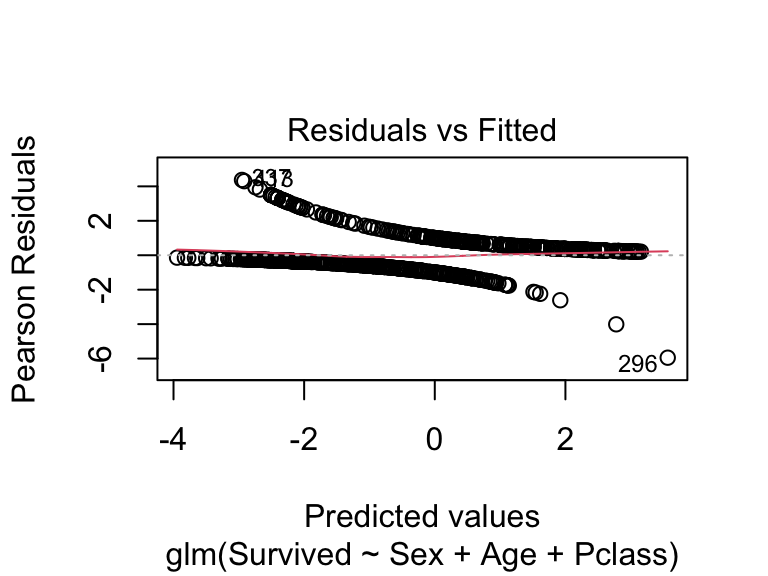

```r
plot(general_model, 1) # plot residuals
```

### Testing for problematic multicollinearity

```r
vif<-car::vif(general_model) # use vif() for testing multicollinearity
knitr::kable(vif) # put it in a nice table
```

|  | GVIF | Df | GVIF^(1/(2*Df)) |
| --- | --- | --- | --- |
| Sex | 1.085634 | 1 | 1.041937 |
| Age | 1.351874 | 1 | 1.162701 |
| Pclass | 1.448873 | 2 | 1.097129 |

- The residual plots and absence of multicollinearity, with GVIF values close to 1 for all predictors, validate the model’s appropriateness.
- The significant p-values (nearly 0) for sex and class imply these factors are statistically significant predictors of survival.

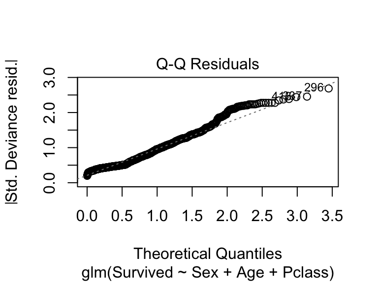

```r
plot(general_model, 2) # plot a QQ plot for residuals
```

The QQ plot (quantile-quantile plot) of residuals is used to assess if the distribution of residuals follows a normal distribution. In an ideal QQ plot, the points should fall along a straight line. Deviations from this line indicate departures from normality, which can affect confidence interval estimation and hypothesis testing. While logistic regression does not assume normality of residuals, the QQ plot can still be useful for identifying extreme values that might influence the model.

```r
# check levels of variables Survived and Pclass
levels(titanic_df$Survived)
```

```
## [1] "0" "1"
```

```r
levels(titanic_df$Pclass)
```

```
## [1] "3" "1" "2"
```

## 1.1 Probabilities of different categories

```r
dummy.coef(tit_1) # getting coefficents of a version of the general model where we plug in the median age
```

```
## Full coefficients are
##
## (Intercept):     -2.222436
## Sex:                  male     female
##                    0.00000    2.63608
## isMedianAge:         FALSE       TRUE
##                  0.0000000 -0.4430419
## Pclass:                  3          1        2
##                   0.000000   1.892572 1.063343
```

```r
# (Survived ~ Sex + isMedianAge + Pclass)
```

### Converting the log-odds estimates to probabilities and into percentages:

```r
Female_actual_prob <-boot::inv.logit(2.6360 + (-2.2224))*100

Male_actual_prob <-boot::inv.logit(0 + (-2.2224))*100

Class3_actual_prob <-boot::inv.logit(0 + (-2.2224))*100

Class1_actual_prob <-boot::inv.logit(1.8925 + (-2.2224))*100

Class2_actual_prob <-boot::inv.logit(1.0633 + (-2.2224))*100

Age_actual_prob <-boot::inv.logit(-0.4430 + (-2.2224))*100
```

```r
# create a pretty table
alive_or_not_actual <-rbind(Female_actual_prob, Male_actual_prob, Class1_actual_prob, Class2_actual_prob, Class3_actual_prob, Age_actual_prob)
knitr::kable(alive_or_not_actual, caption = "Real probabilities of survival for different categories")
```

Real probabilities of survival for different categories

| Female_actual_prob | 60.195078 |
| --- | --- |
| Male_actual_prob | 9.775692 |
| Class1_actual_prob | 41.826496 |
| Class2_actual_prob | 23.883086 |
| Class3_actual_prob | 9.775692 |
| Age_actual_prob | 6.504616 |

## 1.2 Predicting probabilities with the model

```r
#Survived ~ Age + Sex + Pclass
#predicting probabilities of survival for every data point
predicted_probs <- predict(general_model, titanic_df, type = 'response', na.action = na.pass)

#extracting actual data
actual <- titanic_df$Survived

#predicted probabilities of surviving against the actual data
pred_df <- tibble(predicted_probs, actual)

# readability: mark probabilities below 50% survival as death and rest as survival
pred_df <- pred_df %>%
  mutate(predicted_category = if_else(predicted_probs < 0.5, "0", "1"))
pred_df <- pred_df %>%
  mutate(predicted_category = as_factor(predicted_category))

titanic_df <- titanic_df %>%
  mutate(predicted_category = pred_df$predicted_category)
head(pred_df)
```

```
## # A tibble: 6 × 3
##   predicted_probs actual predicted_category
##             <dbl> <fct>  <fct>
## 1          0.103  0      0
## 2          0.912  1      1
## 3          0.572  1      1
## 4          0.919  1      1
## 5          0.0686 0      0
## 6          0.0883 0      0
```

```r
# create confusion matrix
confusion <- titanic_df %>%
  group_by(Actual = factor(Survived, levels = c(0, 1)),
           Predicted = factor(predicted_category, levels = c(0, 1))) %>%
  summarise(Count = n()) %>%
  ungroup()
```

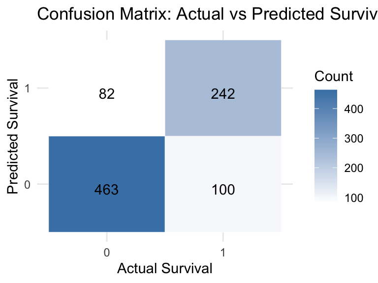

```r
# plot it (total 887 observations)
ggplot(confusion, aes(x = Actual, y = Predicted, fill = Count)) +
  geom_tile(color = "white") +
  geom_text(aes(label = Count), vjust = 1) +
  scale_fill_gradient(low = "white", high = "steelblue") +
  ggtitle("Confusion Matrix: Actual vs Predicted Survival") +
  xlab("Actual Survival") +
  ylab("Predicted Survival") +
  theme_minimal()
```

*The plot in the context of error types in statistics:*

We can see that the model is much better at predicting death than survival in this case.

```r
# create a confusion matrix
confusionMatrix <- caret::confusionMatrix(pred_df$predicted_category, pred_df$actual, positive = "1")
# summarize stats into a table
knitr::kable(confusionMatrix$overall, caption = "Confusion Matrix and Statistics")
```

Confusion Matrix and Statistics

|  | x |
| --- | --- |
| Accuracy | 0.7948140 |
| Kappa | 0.5626588 |
| AccuracyLower | 0.7667147 |
| AccuracyUpper | 0.8209390 |
| AccuracyNull | 0.6144307 |
| AccuracyPValue | 0.0000000 |
| McnemarPValue | 0.2076247 |

```r
# create a table to see other stats
knitr::kable(confusionMatrix$byClass, caption = "Confusion Matrix and Statistics")
```

Confusion Matrix and Statistics

|  | x |
| --- | --- |
| Sensitivity | 0.7076023 |
| Specificity | 0.8495413 |
| Pos Pred Value | 0.7469136 |
| Neg Pred Value | 0.8223801 |
| Precision | 0.7469136 |
| Recall | 0.7076023 |
| F1 | 0.7267267 |
| Prevalence | 0.3855693 |
| Detection Rate | 0.2728298 |
| Detection Prevalence | 0.3652762 |
| Balanced Accuracy | 0.7785718 |

```r
# predicting for separate categories
titanic_df_model <- titanic_df %>%
  mutate (predicted_probs = predict(general_model, titanic_df, type = 'response', na.action = na.pass))

Female <- titanic_df_model  %>%
  filter (Sex == "female")%>%
  summarise(category = "Female", probability = mean(predicted_probs) *100)

Male <- titanic_df_model  %>%
  filter (Sex == "male") %>%
  summarise(probability = mean(predicted_probs) *100, category = "Male")

Class1 <- titanic_df_model  %>%
  filter (Pclass== 1)%>%
  summarise( category = "Class1", probability = mean(predicted_probs) *100)

Class2<- titanic_df_model  %>%
  filter (Pclass == 2) %>%
  summarise(category = "Class2", probability = mean(predicted_probs) *100)

Class3<- titanic_df_model  %>%
  filter (Pclass == 3) %>%
  summarise(category = "Class3", probability = mean(predicted_probs) *100)

Median_Age <- titanic_df_model %>%
  filter (Age == 28) %>%
   summarise(category = "Median Age", probability = mean(predicted_probs) *100)
```

```r
# create a nice table for predictions
alive_or_not <-rbind(Female, Male, Class1, Class2, Class3, Median_Age)
knitr::kable(alive_or_not, caption = "Predicted probabilities of survival for different categories")
```

Predicted probabilities of survival for different categories

| category | probability |
| --- | --- |
| Female | 74.20382 |
| Male | 19.02269 |
| Class1 | 62.96296 |
| Class2 | 47.28261 |
| Class3 | 24.43532 |
| Median Age | 33.65022 |

**The model translated the logistic regression outputs into probabilities:**

- The probability of survival for females was estimated at ~74%, significantly higher than for males at ~19%.
- Passengers in class 1 had a ~63% chance of survival, compared to ~47% and ~24% for classes 2 and 3, respectively.